# Introduction to Seurat

Computational Biology group

2023-07-27

The following material has been adapted from the 2023 Swiss Institute of Bioinformatics single cell RNA sequencing course (https://sib-swiss.github.io/single-cell-training/) authored by Tania Wyss, Rachel Marcone-Jeitziner, Geert van Geest, and Patricia Palagi

## Load relevant packages

```r
library(Seurat)
library(scater)
```

### Set up your R project folder

We will set up a new project, so everything we create is stored in one place. To set up a new project in RStudio, you do the following: File > New Project > New Directory > New Project > set project name. Make sure that the “course_data” that you have downloaded is in this project folder

## Read in data

This is a way of reading in multiple samples at the same time and creating a joint Seurat object. Performing joint normalisation, variable gene selection, scaling can mitigate batch effects. **Note the course_data folder needs to be in your project folder.**

```r
sample_info <- read.csv("course_data/sample_info_course.csv")
datadirs <- file.path("course_data", "count_matrices", sample_info$SampleName,
                      "outs", "filtered_feature_bc_matrix")
names(datadirs) <- gsub("_", "-", sample_info$SampleName)
datadirs <- datadirs[1:3]
```

This is the Seurat function for reading in 10x formatted inputs. Here, the three samples are read in together to make a joint Seurat object.

```r
sparse_matrix <- Seurat::Read10X(data.dir = datadirs)
```

#### Sparse matrix structure

Let’s examine the structure of a sparse matrix by printing the expression values of the first 30 cells for three genes. Note the absence of zeroes

```r
sparse_matrix[c("PECAM1", "CD8A", "TSPAN1"), 1:30]
```

```
## 3 x 30 sparse Matrix of class "dgCMatrix"
```

```
##   [[ suppressing 30 column names 'PBMMC-1_AAACCTGCAGACGCAA-1', 'PBMMC-1_AAACCTGTCATCACCC-1', 'PBMMC-1_AAAGATGCATAAAGGT-1' ... ]]
```

```
##
## PECAM1 . . . . . . . 1 . . . . 1 . . 1 . . . . . . . 1 . . . . . .
## CD8A   . 1 . . 1 . . . . . . . . . . . . . . . . . . . . . . . . .
## TSPAN1 . . . . . . . . . . . . . . . . . . . . . . . . . . . . . .
```

#### A quick demonstration of how much space a sparse matrix saves

Note: There is normally no need to make a dense matrix as it will likely crash your computer

```r
dense_matrix <- as.data.frame(as.matrix(sparse_matrix))
print(object.size(dense_matrix), units = "MB")
```

```
## 1788.7 Mb
```

```r
print(object.size(sparse_matrix), units = "MB")
```

```
## 104.8 Mb
```

```r
# Dense matrix is 17 times bigger
# Remove dense matrix since we don't actually need it
rm(dense_matrix)
```

##### CreateSeuratObject function

Let’s use the help function to look at available options. By default the name of the raw counts assay is RNA. min.cells = include features (genes) that are in at least this many cells, min.features = include cells that have at least this many genes, meta.data = if you have additional information eg sample groups you can pass in a dataframe

```r
seu <- Seurat::CreateSeuratObject(counts = sparse_matrix,
                                  project = "pbmmc",
                                  min.cells = 3,
                                  min.features = 100)
```

Just entering the name of the Seurat object in the console gives us some basic information. It shows the number of features (genes), the number of samples (cells), the number of assays, the active assay, and the number of variable features. More information can be added as we run other functions on the object.

```r
seu
```

```
## An object of class Seurat
## 18673 features across 6946 samples within 1 assay
## Active assay: RNA (18673 features, 0 variable features)
```

##### Alternative approach to loading samples

An alternative approach would be to load the samples, one at a time, into separate Seurat objects and then merge them together using the “merge” function.

There is also a read10X_h5 function if your data is stored in .h5 files.

### Explore the structure of a Seurat object

A Seurat object is an “S4 object” meaning that it has many “slots” for storing information. If you run View(seu), you will see some of the components: reductions = PCA, UMAP, graph = clustering assays = counts, normalised counts

##### Interacting with a Seurat object

```r
View(seu)
```

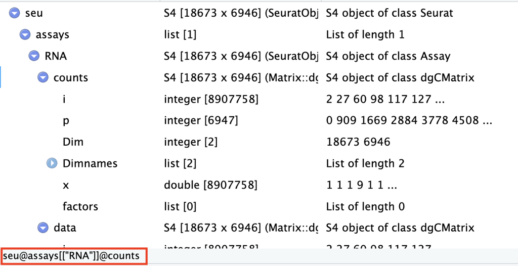

## Seurat functions for extracting individual components

The best (most stable) way of interacting with a Seurat object is by using the accessor functions. These functions are designed to access elements of the Seurat object such as GetAssayData below. If you really get stuck then you can click on components of a Seurat object to find where the information is stored, but generally in R you should try to use accessor functions as they are less likely to change over time. There are also some instances with Seurat objects where there is no explicit accessor function (eg metadata is accessed with double brackets [[]] as shown below).

Here, the GetAssayData function is used

```r
raw_counts <- GetAssayData(object = seu, slot = "counts")
```

The messier alternatives - not recommended

```r
raw_counts <- seu@assays$RNA@counts
raw_counts <- seu@assays[["RNA"]]@counts
```

### FetchData

The fetchData function can be used to extract many different types of information from a Seurat object including counts for individual genes. Here we extract the counts for the CD8A gene across all barcodes

```r
testFetch <- FetchData(object = seu, vars = c("CD8A"))
head(testFetch)
```

```
##                            CD8A
## PBMMC-1_AAACCTGCAGACGCAA-1    0
## PBMMC-1_AAACCTGTCATCACCC-1    1
## PBMMC-1_AAAGATGCATAAAGGT-1    0
## PBMMC-1_AAAGCAAAGCAGCGTA-1    0
## PBMMC-1_AAAGCAACAATAACGA-1    1
## PBMMC-1_AAAGCAACATCAGTCA-1    0
```

#### Some questions

What is active.assay?

What is active.ident?

How many cells in each sample?

The active.assay is the default assay used by Seurat functions, when no particular assay is specified. The active.ident is the default grouping variable used by Seurat functions, when no particular variable is specified. The active.ident can be examined and changed using the Idents function.

```r
# running the summary functions on the Idents output shows how many cells are from each sample
summary(Idents(seu))
```

```
## PBMMC-1 PBMMC-2 PBMMC-3
##    1612    3105    2229
```

### Seurat object metadata

Here metadata refers to information for individual cells. First thing to note is that the metadata is called meta.data not metadata. There is no defined function for extracting metadata, but there is a function for adding metadata to the object (AddMetadata). You can extract columns of the metadata of the seurat object using $ eg seu$nCounts_RNA or extract the metadata as a dataframe using double brackets [[]]. Extracting the metadata as a dataframe is useful for exploratory analysis, particularly if you want to use non-Seurat functions such as ggplot.

How can we get a summary of the orig.ident column without using the Idents function?

```r
summary(seu$orig.ident)
```

```
## PBMMC-1 PBMMC-2 PBMMC-3
##    1612    3105    2229
```

```r
# extract metadata as a dataframe
seu_meta <- seu[[]]

###############################################################################
```

# Adding QC metrics to the Seurat Object

```r
###############################################################################
```

What quality metrics are in the Seurat object already?

```r
head(seu[[]])
```

```
##                            orig.ident nCount_RNA nFeature_RNA
## PBMMC-1_AAACCTGCAGACGCAA-1    PBMMC-1       2401          909
## PBMMC-1_AAACCTGTCATCACCC-1    PBMMC-1       3532          760
## PBMMC-1_AAAGATGCATAAAGGT-1    PBMMC-1       3972         1215
## PBMMC-1_AAAGCAAAGCAGCGTA-1    PBMMC-1       3569          894
## PBMMC-1_AAAGCAACAATAACGA-1    PBMMC-1       2982          730
## PBMMC-1_AAAGCAACATCAGTCA-1    PBMMC-1      22284         3108
```

```r
# nCounts = UMI counts, nFeatures = number of genes detected in the cell
```

## Working with Seurat functions

We progressively add information to the Seurat object using the following syntax: seurat_object <- Seurat::function(seurat_object) Note this syntax overwrites the original object with the output of the function. In the examples below, the function output consists of the original object with added or modified information. **You should always look at the arguments for a Seurat function before running it, as there can be many options. The defaults are often appropriate but may not be optimal for your data.**

## Add in other QC metrics

Common QC metrics include mitochondrial, ribosomal, and haemoglobin percentages. They can be added to a Seurat object by using the PercentageFeatureSet function. Basically, the function searches for patterns within the gene names. The main QC metric to focus on is mitochondrial %. Ribosomal % is often plotted but seldomly used as a QC metric while high haemoglobin % can be a sign of blood cell contamination. They can sometimes give an indication of likely cell type (eg erythroid cells).

```r
# col.name is the name of the column that gets added to the metadata
# add mitochondrial percentage
seu <- Seurat::PercentageFeatureSet(seu,
                                    pattern = "^MT-",
                                    col.name = "percent.mito")
# add ribosomal percentage
seu <- Seurat::PercentageFeatureSet(seu,
                                    pattern = "^RP[SL]",
                                    col.name = "percent.ribo")
# add haemoglobin percentage
seu <- Seurat::PercentageFeatureSet(seu,
                                    pattern = "^HB[^(P)]",
                                    col.name = "percent.globin")
```

##### Note: the pattern arguments differ if you are using mouse data (eg Mt-)

```r
# Inspect the meta.data to see what has changed
head(seu[[]])
```

```
##                            orig.ident nCount_RNA nFeature_RNA percent.mito
## PBMMC-1_AAACCTGCAGACGCAA-1    PBMMC-1       2401          909     2.540608
## PBMMC-1_AAACCTGTCATCACCC-1    PBMMC-1       3532          760     5.181200
## PBMMC-1_AAAGATGCATAAAGGT-1    PBMMC-1       3972         1215     4.934542
## PBMMC-1_AAAGCAAAGCAGCGTA-1    PBMMC-1       3569          894     3.250210
## PBMMC-1_AAAGCAACAATAACGA-1    PBMMC-1       2982          730     3.688799
## PBMMC-1_AAAGCAACATCAGTCA-1    PBMMC-1      22284         3108     3.181655
##                            percent.ribo percent.globin
## PBMMC-1_AAACCTGCAGACGCAA-1     28.65473      0.1665973
## PBMMC-1_AAACCTGTCATCACCC-1     55.03964      0.1981880
## PBMMC-1_AAAGATGCATAAAGGT-1     30.43807      0.3776435
## PBMMC-1_AAAGCAAAGCAGCGTA-1     55.02942      0.3642477
## PBMMC-1_AAAGCAACAATAACGA-1     54.49363      0.1006036
## PBMMC-1_AAAGCAACATCAGTCA-1     23.40693     36.9682283
```

## SingleCellExperiment demonstration and adding extra QC information

Another useful QC metric is showing the % of counts for a cell that come from the top expressed genes in the dataset, as this can identify low complexity cells. Seurat doesn’t have a function for this, but it is possible using the scater package

```r
# Firstly, the seurat object is converted into a SingleCellExperiment
sce <- as.SingleCellExperiment(seu,assay="RNA")

# then the addPerCellQCMetrics function is used to get the percentages
sce <- addPerCellQCMetrics(sce,percent.top=c(50,100,200,500))
```

In a SingleCellExperiment object, metadata can be accessed with the colData function. We can check what has been added by running the head function on the metadata.

```r
#
head(colData(sce))
```

```
## DataFrame with 6 rows and 14 columns
##                            orig.ident nCount_RNA nFeature_RNA percent.mito
##                              <factor>  <numeric>    <integer>    <numeric>
## PBMMC-1_AAACCTGCAGACGCAA-1    PBMMC-1       2401          909      2.54061
## PBMMC-1_AAACCTGTCATCACCC-1    PBMMC-1       3532          760      5.18120
## PBMMC-1_AAAGATGCATAAAGGT-1    PBMMC-1       3972         1215      4.93454
## PBMMC-1_AAAGCAAAGCAGCGTA-1    PBMMC-1       3569          894      3.25021
## PBMMC-1_AAAGCAACAATAACGA-1    PBMMC-1       2982          730      3.68880
## PBMMC-1_AAAGCAACATCAGTCA-1    PBMMC-1      22284         3108      3.18165
##                            percent.ribo percent.globin    ident       sum
##                               <numeric>      <numeric> <factor> <numeric>
## PBMMC-1_AAACCTGCAGACGCAA-1      28.6547       0.166597  PBMMC-1      2401
## PBMMC-1_AAACCTGTCATCACCC-1      55.0396       0.198188  PBMMC-1      3532
## PBMMC-1_AAAGATGCATAAAGGT-1      30.4381       0.377644  PBMMC-1      3972
## PBMMC-1_AAAGCAAAGCAGCGTA-1      55.0294       0.364248  PBMMC-1      3569
## PBMMC-1_AAAGCAACAATAACGA-1      54.4936       0.100604  PBMMC-1      2982
## PBMMC-1_AAAGCAACATCAGTCA-1      23.4069      36.968228  PBMMC-1     22284
##                             detected percent.top_50 percent.top_100
##                            <integer>      <numeric>       <numeric>
## PBMMC-1_AAACCTGCAGACGCAA-1       909        43.2736         56.3515
## PBMMC-1_AAACCTGTCATCACCC-1       760        60.6455         75.7928
## PBMMC-1_AAAGATGCATAAAGGT-1      1215        41.6918         56.9235
## PBMMC-1_AAAGCAAAGCAGCGTA-1       894        51.0507         68.7588
## PBMMC-1_AAAGCAACAATAACGA-1       730        53.7559         71.7304
## PBMMC-1_AAAGCAACATCAGTCA-1      3108        58.0641         69.0989
##                            percent.top_200 percent.top_500     total
##                                  <numeric>       <numeric> <numeric>
## PBMMC-1_AAACCTGCAGACGCAA-1         68.0550         82.9654      2401
## PBMMC-1_AAACCTGTCATCACCC-1         83.3239         92.6387      3532
## PBMMC-1_AAAGATGCATAAAGGT-1         69.3605         81.9990      3972
## PBMMC-1_AAAGCAAAGCAGCGTA-1         78.5374         88.9605      3569
## PBMMC-1_AAAGCAACAATAACGA-1         81.5225         92.2871      2982
## PBMMC-1_AAAGCAACATCAGTCA-1         76.5302         83.7507     22284
```

##### Now the as.Seurat function can be used to move back to a Seurat object again.

```r
seu <- as.Seurat(sce)

# What has changed in our Seurat object
head(seu[[]])
```

```
##                            orig.ident nCount_RNA nFeature_RNA percent.mito
## PBMMC-1_AAACCTGCAGACGCAA-1    PBMMC-1       2401          909     2.540608
## PBMMC-1_AAACCTGTCATCACCC-1    PBMMC-1       3532          760     5.181200
## PBMMC-1_AAAGATGCATAAAGGT-1    PBMMC-1       3972         1215     4.934542
## PBMMC-1_AAAGCAAAGCAGCGTA-1    PBMMC-1       3569          894     3.250210
## PBMMC-1_AAAGCAACAATAACGA-1    PBMMC-1       2982          730     3.688799
## PBMMC-1_AAAGCAACATCAGTCA-1    PBMMC-1      22284         3108     3.181655
##                            percent.ribo percent.globin   ident   sum detected
## PBMMC-1_AAACCTGCAGACGCAA-1     28.65473      0.1665973 PBMMC-1  2401      909
## PBMMC-1_AAACCTGTCATCACCC-1     55.03964      0.1981880 PBMMC-1  3532      760
## PBMMC-1_AAAGATGCATAAAGGT-1     30.43807      0.3776435 PBMMC-1  3972     1215
## PBMMC-1_AAAGCAAAGCAGCGTA-1     55.02942      0.3642477 PBMMC-1  3569      894
## PBMMC-1_AAAGCAACAATAACGA-1     54.49363      0.1006036 PBMMC-1  2982      730
## PBMMC-1_AAAGCAACATCAGTCA-1     23.40693     36.9682283 PBMMC-1 22284     3108
##                            percent.top_50 percent.top_100 percent.top_200
## PBMMC-1_AAACCTGCAGACGCAA-1       43.27364        56.35152        68.05498
## PBMMC-1_AAACCTGTCATCACCC-1       60.64553        75.79275        83.32390
## PBMMC-1_AAAGATGCATAAAGGT-1       41.69184        56.92346        69.36052
## PBMMC-1_AAAGCAAAGCAGCGTA-1       51.05071        68.75876        78.53741
## PBMMC-1_AAAGCAACAATAACGA-1       53.75587        71.73038        81.52247
## PBMMC-1_AAAGCAACATCAGTCA-1       58.06408        69.09891        76.53025
##                            percent.top_500 total
## PBMMC-1_AAACCTGCAGACGCAA-1        82.96543  2401
## PBMMC-1_AAACCTGTCATCACCC-1        92.63873  3532
## PBMMC-1_AAAGATGCATAAAGGT-1        81.99899  3972
## PBMMC-1_AAAGCAAAGCAGCGTA-1        88.96049  3569
## PBMMC-1_AAAGCAACAATAACGA-1        92.28706  2982
## PBMMC-1_AAAGCAACATCAGTCA-1        83.75067 22284
```

```r
# Print the Seurat object
seu
```

```
## An object of class Seurat
## 18673 features across 6946 samples within 1 assay
## Active assay: RNA (18673 features, 0 variable features)
```

```r
# The identifiers have changed, so let's change them back
Idents(seu) <- "orig.ident"
```

### Note on moving between Seurat and SingleCellExperiment objects

Moving between SingleCellExperiment and Seurat objects can be smooth with simple objects (ie no clustering, UMAP, etc) but can be problematic with more complex objects (eg multiple assays, dimensionality reductions, variable features). By problematic, I mean parts of the object can be dropped (ie they disappear). If you need to move to another object format from Seurat, it’s safest to use accessor functions to export relevant parts one at a time (eg GetAssayData) and then use them to make a new object with the SingleCellExperiment() function for a SingleCellExperiment object or using AnnData functions for use in Python. In our example, you could create a SingleCellExperiment using the input counts, run the addPerCellQCMetrics function, and add the metadata from the SingleCellExperiment object to the Seurat object using AddMetaData as shown below (don’t need to run).

```r
# Make a SingleCellExperiment object
sce_object <- SingleCellExperiment(list(counts=sparse_matrix))
# run the same function
sce_object <- addPerCellQCMetrics(sce,percent.top=c(50,100,200,500))
# This is how you could add a metadata column from the sce_object to the Seurat object
# seu <- AddMetaData(seu,metadata = colData(sce)$percent.top_50,col.name = "percent.top_50" )
```

### Add cell cycle score

Seurat has cell cycle genes included and a function for scoring cell cycle phase. Essentially, the function looks at the level of expression of cell cycle marker genes. The original marker genes are in an object called cc.genes while the updated genes are in an object called cc.genes.updated.2019. Note - S phase = (DNA synthesis), G2M - cell cycle pause

```r
seu <- CellCycleScoring(seu,
                        s.features = cc.genes.updated.2019$s.genes,
                        g2m.features = cc.genes.updated.2019$g2m.genes,
                        set.ident = FALSE)
```

### Save Seurat object

You can save a Seurat object as an RData object using the save() function and read it back in again using the load() function

```r
save(seu,file="unfiltered_seu_pbmmc_dataset.RData")
```

### Note

Loading an object with load(“file_name”) will restore the saved object (ie seu). If you want to assign it to a named object, you can use seu_restored <- get(load(“file_name”))